# NMR Data Analysis

Adrianne Seiden

2026-04-09

# Overview

This document outlines the steps for analyzing solid-state <sup>13</sup>C CP/MAS NMR spectra using the `SOMnmR` package in R. The package was developed by Luis Colocho at the Technical University of Munich. You can find the package and its documentation here: https://github.com/LuisCol8/SOMnmR and a peer-reviewed publication describing the methods here: https://doi.org/10.1029%2F2024JG008288.

Full citation: Colocho Hurtarte, L. C., Garcia‐Franco,N., Villalba Ayala, G., Prietzel, J., &Koegel‐Knabner, I. (2025). SOMnmR: An R package for analyzing CP MAS <sup>13</sup>C NMR spectra of environmental samples. *Journal of Geophysical Research: Biogeosciences*, 130, e2024JG008288.

# Basic Integration of NMR Data

modified from SOMnmR “Basic example” vignette: https://github.com/LuisCol8/SOMnmR/blob/main/how-to-use.md

The following code chunk will load and integrate all CP/MAS <sup>13</sup>C NMR spectra stored as comma-separated value (.csv) files in the specified folder. Note that the resulting integrals are not yet spinning side-band (SSB) corrected. There are three integration methods available in the `int_nmr` function: “4region”, “Bonanomi”, and “MMM”. “4region” divides the spectrum into four chemical shift regions:

| Alkyl | 0–45 ppm |
| --- | --- |
| O/N-Alkyl | 45–110 ppm |
| Aryl | 110–160 ppm |
| Carboxyl | 160–210 ppm |

“Bonanomi” uses 7 integration regions defined in [Bonanomi et al., 2011](https://doi.org/10.1111/j.1469-8137.2011.03765.x). This method is used to investigate detailed chemical changes in organic materials, such as during litter decomposition.

| Alkyl | 0–45 ppm |
| --- | --- |
| N-Alkyl/methoxy | 46–60 ppm |
| O-Alkyl | 61–90 ppm |
| Di-O-Alkyl | 91–110 ppm |
| Aromatic | 111–140 ppm |
| Phenolic | 141–160 ppm |
| Carboxyl | 161–190 ppm |

The “MMM” method uses a set of seven integration ranges similar to the “Bonanomi” method, tailored for input into the mixing models based on previous work from [Nelson et al. (1999)](https://doi.org/10.1071/S98076), [Baldock et al. (2004)](https://doi.org/10.1016/j.marchem.2004.06.016) and [Nelson and Baldock (2005)](https://doi.org/10.1007/s10533-004-0076-3).

| Alkyl | −10–45 ppm |
| --- | --- |
| N-Alkyl/methoxy | 45–60 ppm |
| O-Alkyl | 60–95 ppm |
| Di-O-Alkyl | 95–110 ppm |
| Aromatic | 110–145 ppm |
| Phenolic | 145–165 ppm |
| Carbonyl | 165–210 ppm |

To perform the MMM analysis, the SOMnmR package needs both the integrated signal intensities and the molar C:N values of the samples. For now, since I don’t have C:N values for these samples, I will just use the “Bonanomi” method. Note that Phung et al. (in review) uses the MMM integration regions for their A/O-A and RDR calculations (with the exception of ‘Alkyl’ being from 0 to 45 ppm rather than -10 to 45 ppm and ‘Carbonyl’ being from 165 to 215 ppm rather than 165 to 210 ppm).

```r
setwd(csv_folder)

## list all the files
files <- list.files()

## list all the files that end with .csv
files <- files[grep("\\.csv$", files)]

# Load data, choose either  "Bruker" (standard Bruker file), "coma" (coma separated value), "tab" (tab separated value)
spec <- read_raw_spec(files, filetype = "coma")

# Integrate the whole data set, NMRmeth can be "4region", "Bonanomi" and "MMM". I will chose Bonanomi.
# For this you will need to input the magnetic field of your NMR machine and the spinning frequency of the probe.
# In this example we used an NMR of 500 MHz and a spinning frequency of 10,000 Hz.

# Suppress progress bar output
invisible(capture.output(
  Integralregions <- int_nmr(spec, NMRmeth = "Bonanomi", NMR_field = 500, NMR_rotation = 10000)
))

# Display results in the knitted output
print(paste("Integrated", length(Integralregions), "spectra"))
```

```
## [1] "Integrated 25 spectra"
```

```r
# Show the first spectrum's integral table
integral_table <- Integralregions[[1]][["data"]][["Integral"]]
# Round numeric columns to 3 decimal places
integral_table[] <- lapply(integral_table, function(x) if(is.numeric(x)) round(x, 3) else x)
knitr::kable(integral_table,
             caption = "Example: Integral regions for first spectrum")
```

Example: Integral regions for first spectrum

| Integral | From | To | Component | Component_index | Component_ssb | sbb_index | ssb_ofset |
| --- | --- | --- | --- | --- | --- | --- | --- |
| 0.246 | -80 | -70 | NA | NA | Alkyl | 1 | Low |
| 0.575 | -70 | -50 | NA | NA | Alkyl | 2 | Low |
| 0.718 | -50 | -35 | NA | NA | Alkyl | 3 | Low |
| 1.006 | -35 | -20 | NA | NA | Methoxy/N-Alkyl | 4 | Low |
| 2.351 | -20 | 0 | NA | NA | O-Alkyl | 5 | Low |
| 1.399 | 0 | 10 | Alkyl | 1 | O-Alkyl | 6 | Low |
| 5.988 | 10 | 30 | Alkyl | 2 | Di-O-Alkyl | 7 | Low |
| 5.426 | 30 | 45 | Alkyl | 3 | Aromatic | 8 | Low |
| 11.033 | 45 | 60 | Methoxy/N-Alkyl | 4 | Aromatic | 9 | Low |
| 39.739 | 60 | 80 | O-Alkyl | 5 | Phenolic | 10 | Low |
| 9.465 | 80 | 90 | O-Alkyl | 6 | Alkyl | 1 | High |
| 11.706 | 90 | 110 | Di-O-Alkyl | 7 | Alkyl | 2 | High |
| 3.606 | 110 | 125 | Aromatic | 8 | Alkyl | 3 | High |
| 2.070 | 125 | 140 | Aromatic | 9 | Methoxy/N-Alkyl | 4 | High |
| 2.403 | 140 | 160 | Phenolic | 10 | O-Alkyl | 5 | High |
| 0.783 | 160 | 170 | Amide/Carboxyl | 11 | O-Alkyl | 6 | High |
| 1.289 | 170 | 190 | Amide/Carboxyl | 12 | Di-O-Alkyl | 7 | High |
| 0.268 | 190 | 205 | NA | NA | Aromatic | 8 | High |
| 0.099 | 205 | 220 | NA | NA | Aromatic | 9 | High |
| -0.107 | 220 | 240 | NA | NA | Phenolic | 10 | High |
| -0.036 | 240 | 250 | NA | NA | Amide/Carboxyl | 11 | High |
| -0.026 | 250 | 270 | NA | NA | Amide/Carboxyl | 12 | High |

# Correcting for Spinning Side Bands (SSB)

“We now know how to load a spectrum a perform a simple integration. There is a wraped function that performs the integration, and corrects for the SSBs. The example follows”

```r
# load necessary packages
  library(minpack.lm)
  library(quadprog)
  library(pracma)
  library(ggplot2)
  library(data.table)
  library(dplyr)
  library(IntervalSurgeon)
  library(SOMnmR)

# load data
## set working directory
csv_folder <- file.path(box_base, "Salk Institute Project/AKS Salk files/Adrianne_NMR/MNova-CSVs")
outputs_folder <- file.path(box_base, "Salk Institute Project/AKS Salk files/Adrianne_NMR/NMR_analysis_outputs")

## go to directory containing all spectra
setwd(csv_folder)

## list all the files
files <- list.files()

## list all the files that end with .csv
files <- files[grep("\\.csv$", files)]

# Load data, choose either  "Bruker" (standard Bruker file), "coma" (coma separated value), "tab" (tab separated value
spec <- read_raw_spec(files, filetype = "coma")

# Integrate and correct for the SSB of the whole data set, NMRmeth can be "4region", "Bonanomi" and "MMM".
# I will chose Bonanomi.
# For this you will need to input the magnetic field of your NMR machine and the spinning frequency of the probe.
# For this research I used an NMR of 500 MHz and a spinning frequency of 10000 Hz.

# Suppress progress bar output
invisible(capture.output(
  IntegralSSBc <- region_calc(spec, NMRmeth = "Bonanomi", NMR_field = 500, NMR_rotation = 10000)
))

# Convert character columns to numeric in each data frame (except 'name')
IntegralSSBc <- lapply(IntegralSSBc, function(df) {
  for(col in names(df)) {
    if(col != "name") {
      df[[col]] <- as.numeric(df[[col]])
    }
  }
  return(df)
})
#To view the output of a single spectrum
# View(IntegralSSBc[[1]])

# Round and display first spectrum
ssb_table <- IntegralSSBc[[1]]
ssb_table[] <- lapply(ssb_table, function(x) if(is.numeric(x)) round(x, 3) else x)
knitr::kable(ssb_table,
             caption = "Example: SSB-corrected output for a single spectrum")
```

Example: SSB-corrected output for a single spectrum

| name | Alkyl | Amide.Carboxyl | Aromatic | Di.O.Alkyl | Methoxy.N.Alkyl | O.Alkyl | Phenolic |
| --- | --- | --- | --- | --- | --- | --- | --- |
| AS001_13Cwheat_wk0_root_nt8192 | 15.632 | 1.95 | 4.688 | 11.138 | 12.954 | 53.799 | -0.162 |

```r
#Generate a table with all the results instead of having each in a list
Integrall <- NULL
for (i in 1:length(IntegralSSBc)) {
  Integral <- data.frame(IntegralSSBc[[i]], stringsAsFactors = FALSE)
  Integrall <- rbind(Integrall, Integral)
}

# Convert all columns except 'name' to numeric and round to 3 decimals
for(col in names(Integrall)) {
  if(col != "name") {
    Integrall[[col]] <- round(as.numeric(Integrall[[col]]), 3)
  }
}

# Display all results
knitr::kable(Integrall,
             caption = "Results table: All spectra SSB-corrected integrals") %>%
  kableExtra::kable_styling()
```

Results table: All spectra SSB-corrected integrals

| name | Alkyl | Amide.Carboxyl | Aromatic | Di.O.Alkyl | Methoxy.N.Alkyl | O.Alkyl | Phenolic |
| --- | --- | --- | --- | --- | --- | --- | --- |
| AS001_13Cwheat_wk0_root_nt8192 | 15.632 | 1.950 | 4.688 | 11.138 | 12.954 | 53.799 | -0.162 |
| AS012_13Csoy_wk10_root_nt10240 | 12.457 | 4.310 | 7.485 | 12.630 | 9.667 | 51.761 | 1.689 |
| AS029_13Cwheat_wk10_root_nt1024 | 9.467 | 4.999 | 7.798 | 13.077 | 8.995 | 52.565 | 3.098 |
| AS029_13Cwheat_wk40_root_nt16384 | 11.519 | 5.059 | 17.420 | 11.140 | 8.806 | 40.015 | 6.040 |
| AS030_13Csoy_wk10_root_nt8192 | 8.764 | 2.616 | 7.667 | 13.622 | 9.198 | 56.599 | 1.534 |
| AS030_13Csoy_wk40_root_nt32768 | 13.010 | 6.392 | 12.997 | 11.181 | 9.760 | 41.860 | 4.800 |
| AS050_13Csoy_wk0_root_nt1024 | 11.708 | 7.557 | 9.627 | 12.642 | 8.082 | 46.778 | 3.605 |
| AS052_13CnoPlant_wk40_root_nt32768 | 11.972 | 5.603 | 16.056 | 11.418 | 9.232 | 39.928 | 5.793 |
| AS053_13Cwheat_wk10_root_nt16384 | 7.332 | 2.907 | 13.043 | 14.218 | 8.908 | 50.112 | 3.480 |
| AS053_13Cwheat_wk40_root_nt32768 | 10.635 | 4.802 | 18.183 | 11.280 | 9.461 | 39.699 | 5.940 |
| AS055_13Crice_wk40_root_nt16384 | 8.740 | 4.530 | 10.819 | 12.793 | 8.303 | 50.388 | 4.427 |
| AS079_13Crice_wk0_root_nt32768 | 11.789 | 5.218 | 11.486 | 12.452 | 9.137 | 46.344 | 3.574 |
| AS080_13Csoy_wk10_root_nt8192 | 10.831 | 5.169 | 11.634 | 12.684 | 9.863 | 46.450 | 3.370 |
| AS080_13Csoy_wk40_root_nt4096 | 8.102 | 3.900 | 11.991 | 11.551 | 10.659 | 48.681 | 5.116 |
| AS087_13Crice_wk10_root_nt22528 | 8.858 | 4.428 | 11.254 | 12.820 | 10.006 | 48.651 | 3.984 |
| AS087_13Crice_wk40_root_nt1024 | 8.948 | 4.461 | 9.132 | 12.762 | 8.005 | 52.972 | 3.720 |
| AS094_13Csoy_wk40_root_nt1024 | 10.186 | 4.327 | 11.022 | 11.404 | 9.785 | 48.698 | 4.579 |
| AS103_13Crice_wk0_root_nt5464 | 5.176 | 5.405 | 13.914 | 13.931 | 6.217 | 50.092 | 5.266 |
| AS119_13Crice_wk10_root_nt24576 | 9.460 | 4.407 | 9.710 | 13.093 | 8.401 | 51.741 | 3.188 |
| SC032_13Cwheat_wk0_root_nt2048_d1_2 | 2.706 | 4.526 | 11.456 | 14.824 | 5.649 | 55.399 | 5.440 |
| SC055_13Crice_wk10_root_nt2048 | 10.857 | 2.958 | 6.683 | 12.650 | 10.726 | 54.310 | 1.817 |
| SC062_13Csoy_wk0_root_nt2048_d1_2 | 14.455 | 6.322 | 7.834 | 11.963 | 9.880 | 47.397 | 2.149 |
| SC094_13Csoy_wk10_root_nt2048 | 13.601 | 5.889 | 7.493 | 12.113 | 9.036 | 49.518 | 2.350 |
| SC103_13Crice_wk0_root_nt32768 | 7.369 | 4.119 | 11.914 | 13.763 | 5.676 | 52.826 | 4.333 |
| SC107_12Crice_wk0_root_nt32768 | 7.369 | 4.119 | 11.914 | 13.763 | 5.676 | 52.826 | 4.333 |

```r
# Save the results as a .csv file
write.csv(Integrall, file.path(outputs_folder, "NMR_SSB_corrected_integrals_Bonanomi.csv"), row.names = FALSE)
```

# Make a plot

“There is a quick plot function that separates the regions of the spectrum.” – I modified plot_NMR to plot 230 to -20 ppm instead of 400 to -200 ppm, set the y-minimum at -0.1 (instead of -5), and use the sample names as plot titles.

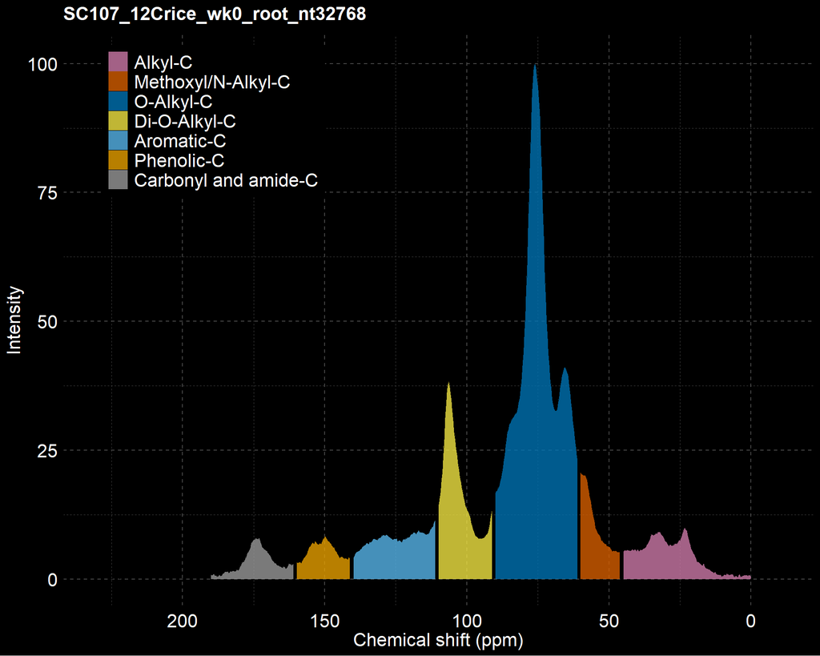

```r
# load necessary packages
  library(ggplot2)
  library(SOMnmR)

# Source the custom function from adrianne-code directory (use absolute path)
source(file.path(dirname(getwd()), "adrianne-code", "plot_NMR_edit.R"))

# Set working directory to outputs folder for plot saving
setwd(outputs_folder)

# Generate plots - they will be saved to outputs_folder and displayed in HTML
plot_NMR_aks(spec, NMRmeth = "Bonanomi", file.output = TRUE , use.tiff = FALSE)
```

```r
# Return to original directory
setwd(csv_folder)
```

# Calculate Alkyl/O-Alkyl Ratios (A/O-A) and Resistance-to-Decomposition Ratios (RDR).

A/O-A ratio is calculated as the ratio of the integrated signal intensities in the alkyl-C (**0–45 ppm**) and O-alkyl-C (**61–90 ppm**) regions, according to the Bonanomi method. Note that Phung et al. (in review) uses **60–95 ppm** as the O-alkyl region, which is more similar to the MMM integration.

RDR is calculated according to Phung et al. (in review): **(alkyl + aromatic + phenolic)/(O-alkyl + carboxyl + carbonyl)**.  
Using the Bonanomi integration regions, this corresponds to **(0–45 ppm + 111-160 ppm)/(61–90 ppm + 161–190 ppm)**, but Phung et al. (in review) uses **(0–45 ppm + 110–165 ppm)/(60–95 ppm + 165–215 ppm)** for their calculations.

```r
# Read the SSB-corrected integrals CSV
ratios_df <- read.csv(file.path(outputs_folder, "NMR_SSB_corrected_integrals_Bonanomi.csv"))

# Calculate alkyl/O-alkyl ratio
ratios_df$Alkyl_O.Alkyl_Ratio <- ratios_df$Alkyl / ratios_df$O.Alkyl

# Round the new ratio column to 3 decimal places
ratios_df$Alkyl_O.Alkyl_Ratio <- round(ratios_df$Alkyl_O.Alkyl_Ratio, 3)

# Calculate RDR
ratios_df$RDR <- (ratios_df$Alkyl + ratios_df$Aromatic + ratios_df$Phenolic) / (ratios_df$O.Alkyl + ratios_df$Amide.Carboxyl)

# Round the new ratio column to 3 decimal places
ratios_df$RDR <- round(ratios_df$RDR, 3)

# Save updated CSV with ratios
write.csv(ratios_df, file.path(outputs_folder, "NMR_SSB_corrected_integrals_Bonanomi.csv"), row.names = FALSE)

# Extract crop and timepoint from sample names
# Assuming format like "AS1_noPlant_wk0" or similar
ratios_df$crop <- sub(".*(noPlant|wheat|rice|soy)_.*", "\\1", ratios_df$name)
ratios_df$timepoint <- sub(".*_(wk[0-9]+).*", "\\1", ratios_df$name)

# Calculate mean alkyl/O-alkyl ratio grouped by crop and timepoint
ratio_means <- ratios_df %>%
  group_by(crop, timepoint) %>%
  summarise(
    n_samples = n(),
    mean_Alkyl_O.Alkyl = round(mean(Alkyl_O.Alkyl_Ratio, na.rm = TRUE), 3),
    sd_Alkyl_O.Alkyl = round(sd(Alkyl_O.Alkyl_Ratio, na.rm = TRUE), 3),
    mean_RDR = round(mean(RDR, na.rm = TRUE), 3),
    sd_RDR = round(sd(RDR, na.rm = TRUE), 3),
    .groups = 'drop'
  )

# Display the results
knitr::kable(ratio_means,
             caption = "Mean Alkyl/O-Alkyl and RDR by Crop and Timepoint") %>%
  kableExtra::kable_styling()
```

Mean Alkyl/O-Alkyl and RDR by Crop and Timepoint

| crop | timepoint | n_samples | mean_Alkyl_O.Alkyl | sd_Alkyl_O.Alkyl | mean_RDR | sd_RDR |
| --- | --- | --- | --- | --- | --- | --- |
| noPlant | wk40 | 1 | 0.300 | NA | 0.743 | NA |
| rice | wk0 | 4 | 0.159 | 0.066 | 0.448 | 0.050 |
| rice | wk10 | 3 | 0.188 | 0.010 | 0.397 | 0.058 |
| rice | wk40 | 2 | 0.171 | 0.003 | 0.408 | 0.040 |
| soy | wk0 | 2 | 0.277 | 0.039 | 0.457 | 0.003 |
| soy | wk10 | 4 | 0.226 | 0.051 | 0.403 | 0.082 |
| soy | wk40 | 3 | 0.229 | 0.074 | 0.534 | 0.090 |
| wheat | wk0 | 2 | 0.170 | 0.171 | 0.345 | 0.025 |
| wheat | wk10 | 2 | 0.163 | 0.024 | 0.402 | 0.068 |
| wheat | wk40 | 2 | 0.278 | 0.014 | 0.778 | 0.004 |

```r
# Save the summary table
write.csv(ratio_means, file.path(outputs_folder, "NMR_ratio_means.csv"), row.names = FALSE)
```

# Plot A/O-A and RDR Over Time

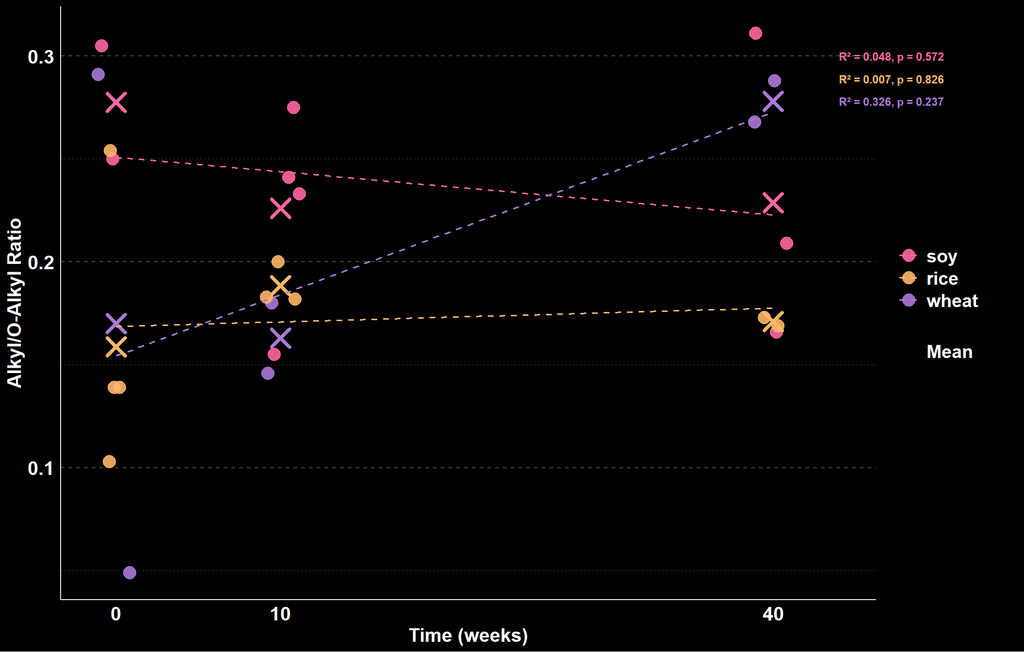

```r
library(ggplot2)

# Filter out noPlant and prepare data
plot_data <- ratios_df %>%
  filter(crop %in% c("wheat", "rice", "soy")) %>%
  mutate(
    crop = factor(crop, levels = c("soy", "rice", "wheat")),
    timepoint_num = as.numeric(gsub("wk", "", timepoint)),
    crop_time = paste(crop, timepoint, sep = "_")
  )

# Calculate means for each crop-timepoint combination
plot_means <- plot_data %>%
  group_by(crop, timepoint_num) %>%
  summarise(mean_ratio = mean(Alkyl_O.Alkyl_Ratio, na.rm = TRUE), .groups = 'drop')

# Calculate R² and p-values for each crop
lm_stats <- plot_data %>%
  group_by(crop) %>%
  summarise(
    model = list(lm(Alkyl_O.Alkyl_Ratio ~ timepoint_num)),
    r_squared = summary(model[[1]])$r.squared,
    p_value = summary(model[[1]])$coefficients[2, 4],
    .groups = 'drop'
  ) %>%
  mutate(
    label = sprintf("R² = %.3f, p = %.3f", r_squared, p_value),
    x = 44,  # Position for text (outside plot area)
    y = case_when(
      crop == "soy" ~ 0.3,
      crop == "rice" ~ 0.289,
      crop == "wheat" ~ 0.278
    )
  )

# Create the A/O-A plot
p <- ggplot(plot_data, aes(x = timepoint_num, y = Alkyl_O.Alkyl_Ratio, fill = crop, color = crop)) +
  geom_jitter(width = 1.2, height = 0, alpha = 0.9, size = 4.5) +
  geom_point(data = plot_means, aes(x = timepoint_num, y = mean_ratio, color = crop),
             shape = 4, size = 5.2, stroke = 2, show.legend = FALSE) +
  # Add a dummy point for legend only
  geom_point(aes(shape = "Mean"), x = NA, y = NA, color = "black", size = 5.2, stroke = 2) +
  geom_smooth(aes(group = crop, color = crop),
              method = "lm", se = FALSE, linetype = "dashed",
              linewidth = 0.7) +
  geom_text(data = lm_stats, aes(x = x, y = y, label = label, color = crop),
            size = 3, fontface = "bold", hjust = 0, show.legend = FALSE) +
  coord_cartesian(clip = "off") +
  scale_x_continuous(breaks = c(0, 10, 40)) +
  scale_fill_manual(values = crop_color, name = NULL, guide = "none") +
  scale_color_manual(values = crop_color, name = NULL,
                     guide = guide_legend(order = 1, override.aes = list(shape = 16, size = 4.5))) +
  scale_shape_manual(values = 4, name = NULL,
                     guide = guide_legend(order = 2, override.aes = list(size = 5.2, stroke = 2))) +
  labs(
    x = "Time (weeks)",
    y = "Alkyl/O-Alkyl Ratio",
    title = NULL
  ) +

  theme(
    legend.position = "right",
    legend.text = element_text(size = 14, face = "bold"),
    axis.title = element_text(size = 14.5, face = "bold"),
    axis.text = element_text(size = 14.5, face = "bold"),
    panel.grid.major.x = element_blank(),
    panel.grid.minor.x = element_blank(),
    # panel.grid.major.y = element_line(color = "#4a4a4a", size = 0.25, linetype = "solid"),
    # panel.grid.minor.y = element_line(color = "#303030", size = 0.15, linetype = "solid"),
    plot.margin = margin(5, 30, 5, 5)
  )

# Display the plot
print(p)
```

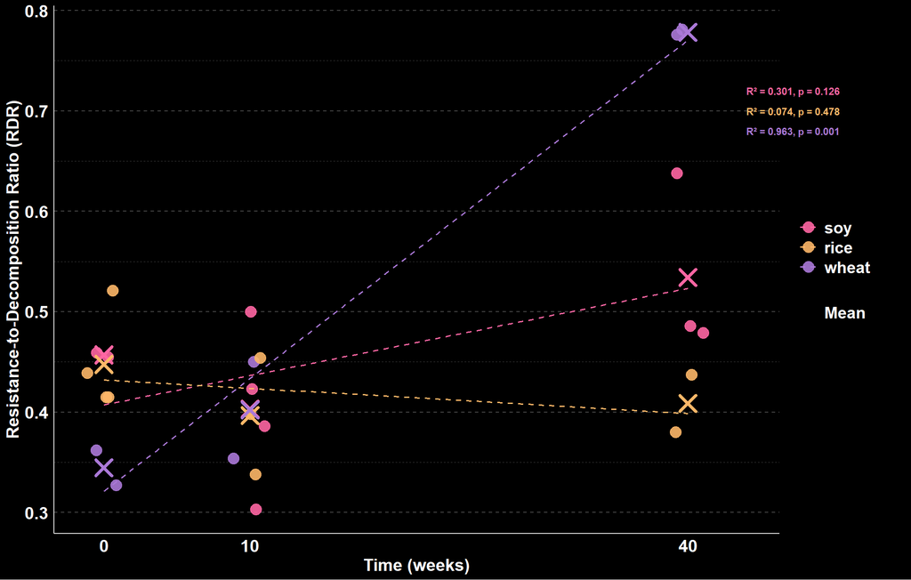

```r
# Save the plot
ggsave_themed(filename = "Alkyl_O-Alkyl_ratio_by_crop_timepoint.png",
              plot = p, width = 11, height = 7, dpi = 300)
###########################################################################################

# Create the RDR plot
# Calculate means for each crop-timepoint combination
rdr_means <- plot_data %>%
  group_by(crop, timepoint_num) %>%
  summarise(mean_rdr = mean(RDR, na.rm = TRUE), .groups = 'drop')

# Calculate R² and p-values for RDR
rdr_lm_stats <- plot_data %>%
  group_by(crop) %>%
  summarise(
    model = list(lm(RDR ~ timepoint_num)),
    r_squared = summary(model[[1]])$r.squared,
    p_value = summary(model[[1]])$coefficients[2, 4],
    .groups = 'drop'
  ) %>%
  mutate(
    label = sprintf("R² = %.3f, p = %.3f", r_squared, p_value),
    x = 44,  # Position for text (outside plot area)
    y = case_when(
      crop == "soy" ~ 0.72,
      crop == "rice" ~ 0.70,
      crop == "wheat" ~ 0.68
    )
  )

p1 <- ggplot(plot_data, aes(x = timepoint_num, y = RDR, fill = crop, color = crop)) +
  geom_jitter(width = 1.2, height = 0, alpha = 0.9, size = 4.5) +
    geom_point(data = rdr_means, aes(x = timepoint_num, y = mean_rdr, color = crop),
             shape = 4, size = 5.2, stroke = 2, show.legend = FALSE) +
  # Add a dummy point for legend only
  geom_point(aes(shape = "Mean"), x = NA, y = NA, color = "black", size = 5.2, stroke = 2) +
  geom_smooth(aes(group = crop, color = crop),
              method = "lm", se = FALSE, linetype = "dashed",
              linewidth = 0.7) +
  geom_text(data = rdr_lm_stats, aes(x = x, y = y, label = label, color = crop),
            size = 3, fontface = "bold", hjust = 0, show.legend = FALSE) +
  coord_cartesian(clip = "off") +
  scale_x_continuous(breaks = c(0, 10, 40)) +
  scale_fill_manual(values = crop_color, name = NULL, guide = "none") +
  scale_color_manual(values = crop_color, name = NULL,
                     guide = guide_legend(order = 1, override.aes = list(shape = 16, size = 4.5))) +
  scale_shape_manual(values = 4, name = NULL,
                     guide = guide_legend(order = 2, override.aes = list(size = 5.2, stroke = 2))) +
  labs(
    x = "Time (weeks)",
    y = "Resistance-to-Decomposition Ratio (RDR)",
    title = NULL
  ) +

  theme(
    legend.position = "right",
    legend.text = element_text(size = 14, face = "bold"),
    axis.title = element_text(size = 14.5, face = "bold"),
    axis.text = element_text(size = 14.5, face = "bold"),
    panel.grid.major.x = element_blank(),
    panel.grid.minor.x = element_blank(),
    # panel.grid.major.y = element_line(color = "#4a4a4a", size = 0.25, linetype = "solid"),
    # panel.grid.minor.y = element_line(color = "#303030", size = 0.15, linetype = "solid"),
    plot.margin = margin(5, 30, 5, 5)
  )

# Display the plot
print(p1)
```

```r
# Save the plot
ggsave_themed(filename = "RDR_by_crop_timepoint.png",
              plot = p1, width = 11, height = 7, dpi = 300)
```

# Plot RDR vs Alkyl/O-Alkyl Ratio

Plot the relationship between Resistance to Decomposition Ratio (RDR) and Alkyl/O-Alkyl ratio, colored by crop-timepoint combination.

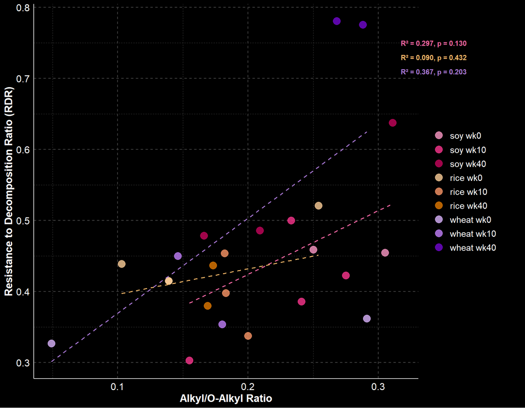

```r
library(ggplot2)

# Prepare data with crop_time variable
scatter_data <- plot_data %>%
  mutate(crop_time = paste(crop, "wk", timepoint_num, sep = "_"),
         crop_time = gsub("_wk_", "_wk", crop_time))

# Calculate R² and p-values for scatter plot
scatter_lm_stats <- scatter_data %>%
  group_by(crop) %>%
  summarise(
    model = list(lm(RDR ~ Alkyl_O.Alkyl_Ratio)),
    r_squared = summary(model[[1]])$r.squared,
    p_value = summary(model[[1]])$coefficients[2, 4],
    .groups = 'drop'
  ) %>%
  mutate(
    label = sprintf("R² = %.3f, p = %.3f", r_squared, p_value),
    x = max(scatter_data$Alkyl_O.Alkyl_Ratio, na.rm = TRUE) * 1.02,
    y = case_when(
      crop == "soy" ~ 0.75,
      crop == "rice" ~ 0.73,
      crop == "wheat" ~ 0.71
    )
  )

# Create scatter plot
p_scatter <- ggplot(scatter_data, aes(x = Alkyl_O.Alkyl_Ratio, y = RDR)) +
  geom_point(aes(color = crop_time), size = 4, alpha = 0.8) +
  geom_smooth(aes(group = crop, color = crop),
            method = "lm", se = FALSE, linetype = "dashed",
            linewidth = 0.7, show.legend = FALSE) +
  geom_text(data = scatter_lm_stats, aes(x = x, y = y, label = label, color = crop),
            size = 3, fontface = "bold", hjust = 0, show.legend = FALSE) +
  coord_cartesian(clip = "off") +
  scale_color_manual(values = c(color_map, crop_color),
                     breaks = names(color_map),
                     labels = c("soy wk0", "soy wk10", "soy wk40",
                               "rice wk0", "rice wk10", "rice wk40",
                               "wheat wk0", "wheat wk10", "wheat wk40"),
                     name = NULL) +
  labs(
    x = "Alkyl/O-Alkyl Ratio",
    y = "Resistance to Decomposition Ratio (RDR)",
    title = NULL
  ) +

  theme(
    legend.position = "right",
    legend.text = element_text(size = 11),
    axis.title = element_text(size = 13, face = "bold"),
    axis.text = element_text(size = 12),
    plot.margin = margin(5, 30, 5, 5),
    #  panel.grid.major.y = element_line(color = "#4a4a4a", size = 0.25, linetype = "solid"),
    # panel.grid.minor.y = element_line(color = "#303030", size = 0.15, linetype = "solid"),
    # panel.grid.major.x = element_line(color = "#4a4a4a", size = 0.25, linetype = "solid"),
    # panel.grid.minor.x = element_line(color = "#303030", size = 0.15, linetype = "solid")
  )

# Display the plot
print(p_scatter)
```

```r
# Save the plot
ggsave_themed(filename = "RDR_vs_Alkyl-O-Alkyl_ratio.png",
              plot = p_scatter, width = 11, height = 7, dpi = 300)
```

# Plot Averaged NMR Spectra by Crop and Timepoint

Create plots showing mean NMR spectra for each crop-timepoint combination with standard deviation and full range. The solid line represents the mean spectrum, the medium transparency ribbon represents ±1 standard deviation, and the most transparent ribbon represents the full range (min to max) of spectra at each ppm value (may be the same as ±1 standard deviation).

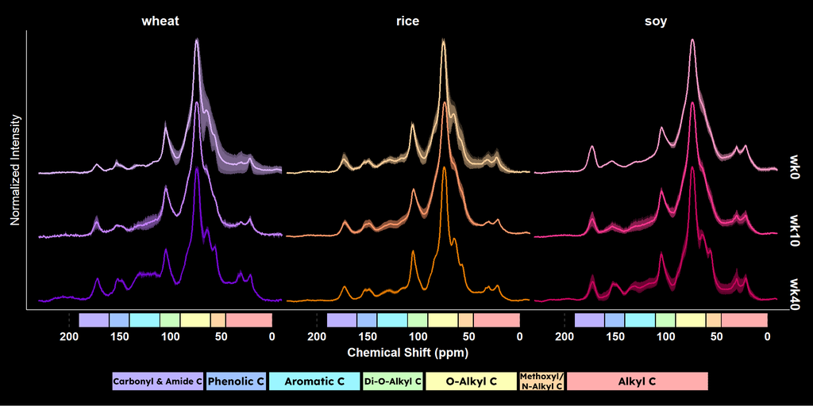

```r
library(ggplot2)
library(dplyr)
library(tidyr)

# Extract all spectra into a data frame
spectra_list <- lapply(seq_along(spec), function(i) {
  df <- spec[[i]]$data$raw.spec
  # Select ppm and raw.intensity columns and rename
  df <- data.frame(
    ppm = df$ppm,
    intensity = df$raw.intensity,
    sample_name = spec[[i]]$name
  )
  return(df)
})

spectra_df <- bind_rows(spectra_list)

# Extract crop and timepoint from sample names
spectra_df$crop <- sub(".*(noPlant|wheat|rice|soy)_.*", "\\1", spectra_df$sample_name)
spectra_df$timepoint <- sub(".*_(wk[0-9]+).*", "\\1", spectra_df$sample_name)

# Filter for crops of interest and ppm range
spectra_filtered <- spectra_df %>%
  filter(crop %in% c("wheat", "rice", "soy"),
         ppm >= -10 & ppm <= 230) %>%
  mutate(crop = factor(crop, levels = c("wheat", "rice", "soy")))

# Calculate statistics by crop, timepoint, and ppm
spectra_stats <- spectra_filtered %>%
  group_by(crop, timepoint, ppm) %>%
  summarise(
    mean_intensity = mean(intensity),
    sd_intensity = sd(intensity),
    min_intensity = min(intensity),
    max_intensity = max(intensity),
    .groups = 'drop'
  ) %>%
  mutate(
    upper_sd = mean_intensity + sd_intensity,
    lower_sd = mean_intensity - sd_intensity,
    crop_time = paste(crop, timepoint, sep = "_")
  )

# Create the main plot without annotation
p_spectra <- ggplot(spectra_stats, aes(x = ppm, y = mean_intensity, color = crop_time, fill = crop_time)) +
  # Full range (most transparent)
  geom_ribbon(aes(ymin = min_intensity, ymax = max_intensity), alpha = 0.19, color = NA) +
  # +/- 1 SD (medium transparency)
  geom_ribbon(aes(ymin = lower_sd, ymax = upper_sd), alpha = 0.44, color = NA) +
  # Mean line (solid)
  geom_line(linewidth = 0.8) +
  facet_grid(timepoint ~ crop, scales = "free_y") +
  scale_x_reverse() +
  scale_color_manual(values = color_map) +
  scale_fill_manual(values = color_map) +
  labs(
    x = NULL,  # Remove x-axis label from main plot
    y = "Normalized Intensity",
    title = NULL
  ) +

  theme(
    legend.position = "none",
    strip.text = element_text(size = 14, face = "bold", color = annotation_text_color),
    # strip.background = element_rect(fill = "#1a1a1a"),
    strip.text.y = element_text(margin = margin(t = 130, r = 1, b = 0, l = 0), color = annotation_text_color),
    # panel.grid = element_blank(),
    panel.grid.major.y = element_blank(),
    panel.grid.minor.y = element_blank(),
    panel.grid.major.x = element_blank(),
    panel.grid.minor.x = element_blank(),
    axis.title = element_text(size = 13),
    axis.text.x = element_blank(),  # Remove x-axis text from main plot
    axis.text.y = element_blank(),
    panel.spacing.x = unit(-0.75, "cm"),
    panel.spacing.y = unit(-3.3, "cm"),
    plot.margin = margin(t = 5, r = 5, b = 1, l = 5)
  )

# Create annotation bar as a separate plot

# Define Bonanomi regions for annotation strip
bonanomi_regions <- data.frame(
  region = c("Alkyl", "N-Alkyl/\nmethoxy", "O-Alkyl", "Di-O-\nAlkyl", "Aromatic", "Phenolic", "Carboxyl"),
  xmin = c(0, 46, 61, 91, 111, 141, 161),
  xmax = c(45, 60, 90, 110, 140, 160, 190),
  color = c("#ffadad", "#ffd6a5", "#fdffb6", "#caffbf", "#9bf6ff", "#a0c4ff", "#bdb2ff")
)

# Create annotation bars for each crop (to match facet columns)
bonanomi_regions_faceted <- bind_rows(
  bonanomi_regions %>% mutate(crop = "soy"),
  bonanomi_regions %>% mutate(crop = "rice"),
  bonanomi_regions %>% mutate(crop = "wheat")
)

p_annotation <- ggplot(bonanomi_regions_faceted) +
  geom_rect(aes(xmin = xmin, xmax = xmax, ymin = 0, ymax = 0.7, fill = color)) +
  scale_fill_identity() +
  scale_x_reverse(limits = c(230, -10)) +
  scale_y_continuous(limits = c(0, 0.7), expand = c(0, 0)) +
  facet_grid(. ~ crop) +
  labs(x = "Chemical Shift (ppm)") +

  theme(
    axis.title.x = element_text(size = 13, face = "bold", margin = margin(t = 5)),
    axis.text.x = element_text(size = 12, face = "bold"),
    axis.title.y = element_blank(),
    axis.text.y = element_blank(),
    axis.ticks.y = element_blank(),
    panel.grid.major.y = element_blank(),
    panel.grid.minor.y = element_blank(),
    panel.grid.panel.grid.major.x = element_blank(),
    panel.grid.minor.x = element_blank(),
    panel.spacing.x = unit(-0.75, "cm"),
    strip.text = element_blank(),
    axis.line = element_blank(),
    plot.margin = margin(0, 5, 5, 5)
  )
# ggsave(filename = "NMR_annotation_strip.png", plot = p_annotation, width = 49, height = 1.15, dpi = 500)
# Load the NMR annotations image and create a plot for it
nmr_img <- readPNG("NMR_annotation_strip.png")
img_dim <- dim(nmr_img)
img_aspect_ratio <- img_dim[1] / img_dim[2]  # height / width

p_image <- ggplot() +
  annotation_custom(rasterGrob(nmr_img, width = unit(1, "npc"), height = unit(1, "npc"),
                                just = "center"),
                    xmin = -Inf, xmax = Inf, ymin = -Inf, ymax = Inf) +
  theme_void() +
  theme(plot.margin = margin(5, 5, 5, 5), aspect.ratio = img_aspect_ratio)

# Combine plots vertically
p_combined <- p_spectra / p_annotation / p_image + plot_layout(heights = c(20, 1, 2))

# Display the plot
print(p_combined)
```

```r
# Save the plot
ggsave_themed(filename = "NMR_spectra_averaged_annotated.png",
              plot = p_combined, width = 12, height = 6, dpi = 300)
```

# Plot Alkyl & Alkyl-Suberin Region

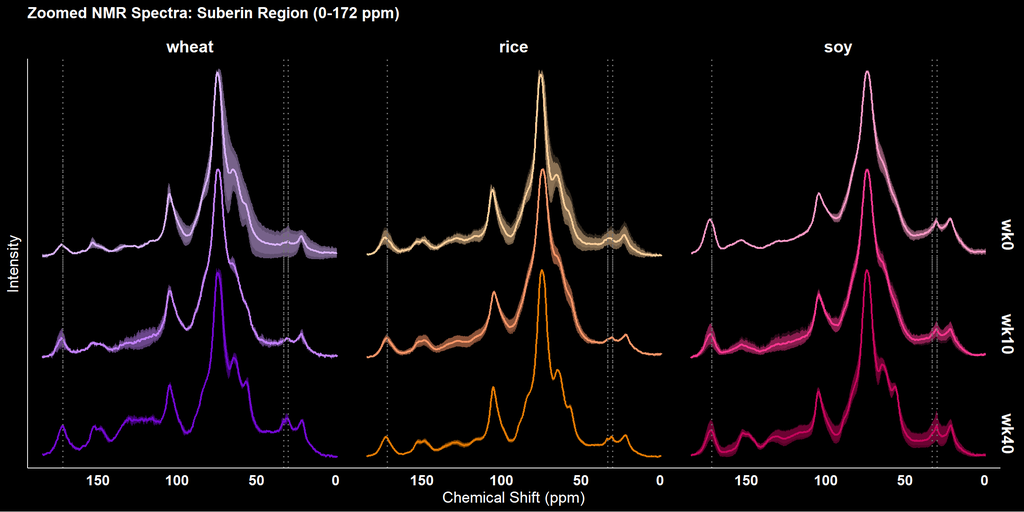

```r
# Filter data for suberin region (0-172 ppm)
spectra_stats_suber <- spectra_stats %>%
  filter(ppm >= -1 & ppm <= 185)

# Create the zoomed plot
p_suber <- ggplot(spectra_stats_suber, aes(x = ppm, y = mean_intensity, color = crop_time, fill = crop_time)) +
  # Full range (most transparent)
  geom_ribbon(aes(ymin = min_intensity, ymax = max_intensity), alpha = 0.19, color = NA) +
  # +/- 1 SD (medium transparency)
  geom_ribbon(aes(ymin = lower_sd, ymax = upper_sd), alpha = 0.44, color = NA) +
  # Mean line (solid)
  geom_line(linewidth = 0.8) +
  # Add vertical reference lines
  geom_vline(xintercept = 172, linetype = "dotted", color = annotation_line_color, linewidth = 0.65) +
  geom_vline(xintercept = 33, linetype = "dotted", color = annotation_line_color, linewidth = 0.65) +
  geom_vline(xintercept = 30, linetype = "dotted", color = annotation_line_color, linewidth = 0.65) +
  facet_grid(timepoint ~ crop, scales = "free_y") +
  scale_x_reverse() +
  scale_color_manual(values = color_map) +
  scale_fill_manual(values = color_map) +
  labs(
    x = "Chemical Shift (ppm)",
    y = "Intensity",
    title = "Zoomed NMR Spectra: Suberin Region (0-172 ppm)"
  ) +

  theme(
    legend.position = "none",
    strip.text = element_text(size = 14, face = "bold", color = annotation_text_color),
    # strip.background = element_rect(fill = "#1a1a1a"),
    strip.text.y = element_text(margin = margin(t = 120, r = 1, b = 0, l = 0), color = annotation_text_color),
    panel.grid.major.y = element_blank(),
    panel.grid.minor.y = element_blank(),
    panel.grid.major.x = element_blank(),
    panel.grid.minor.x = element_blank(),
    axis.title = element_text(size = 13),
    axis.text.x = element_text(size = 12, face = "bold"),
    axis.text.y = element_blank(),
    panel.spacing.x = unit(0, "cm"),
    panel.spacing.y = unit(-3.3, "cm"),
    panel.grid = element_blank()
  )

# Display the plot
print(p_suber)
```

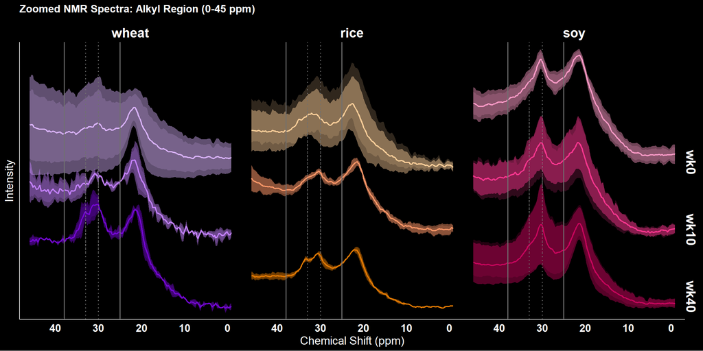

```r
# Save the plot
ggsave_themed(filename = "NMR_spectra_suber_region_0-172ppm.png",
              plot = p_suber, width = 11, height = 7, dpi = 300)




##########################################
# Filter data for alkyl region (0-45 ppm)
spectra_stats_alkyl <- spectra_stats %>%
  filter(ppm >= -1 & ppm <= 46)

# Create the zoomed plot
p_alkyl <- ggplot(spectra_stats_alkyl, aes(x = ppm, y = mean_intensity, color = crop_time, fill = crop_time)) +
  # Full range (most transparent)
  geom_ribbon(aes(ymin = min_intensity, ymax = max_intensity), alpha = 0.19, color = NA) +
  # +/- 1 SD (medium transparency)
  geom_ribbon(aes(ymin = lower_sd, ymax = upper_sd), alpha = 0.44, color = NA) +
  # Mean line (solid)
  geom_line(linewidth = 0.8) +
  # Add vertical reference lines
  geom_vline(xintercept = 33, linetype = "dotted", color = annotation_line_color, linewidth = 0.7) +
  geom_vline(xintercept = 30, linetype = "dotted", color = annotation_line_color, linewidth = 0.7) +
  geom_vline(xintercept = 25, linetype = "solid", color = annotation_line_color, linewidth = 0.55) +
  geom_vline(xintercept = 38, linetype = "solid", color = annotation_line_color, linewidth = 0.55) +
  facet_grid(timepoint ~ crop, scales = "free_y") +
  scale_x_reverse() +
  scale_color_manual(values = color_map) +
  scale_fill_manual(values = color_map) +
  labs(
    x = "Chemical Shift (ppm)",
    y = "Intensity",
    title = "Zoomed NMR Spectra: Alkyl Region (0-45 ppm)"
  ) +

  theme(
    legend.position = "none",
    strip.text = element_text(size = 16, face = "bold", color = annotation_text_color),
    # strip.background = element_rect(fill = "#1a1a1a"),
    strip.text.y = element_text(margin = margin(t = 120, r = 1, b = 0, l = 0), color = annotation_text_color),
    axis.title = element_text(size = 14),
    axis.text.x = element_text(size = 13, face = "bold"),
    axis.text.y = element_blank(),
    panel.grid.major.y = element_blank(),
    panel.grid.minor.y = element_blank(),
    panel.grid.major.x = element_blank(),
    panel.grid.minor.x = element_blank(),
    panel.spacing.x = unit(0, "cm"),
    panel.spacing.y = unit(-3.3, "cm"),
    panel.grid = element_blank()
  )

# Display the plot
print(p_alkyl)
```

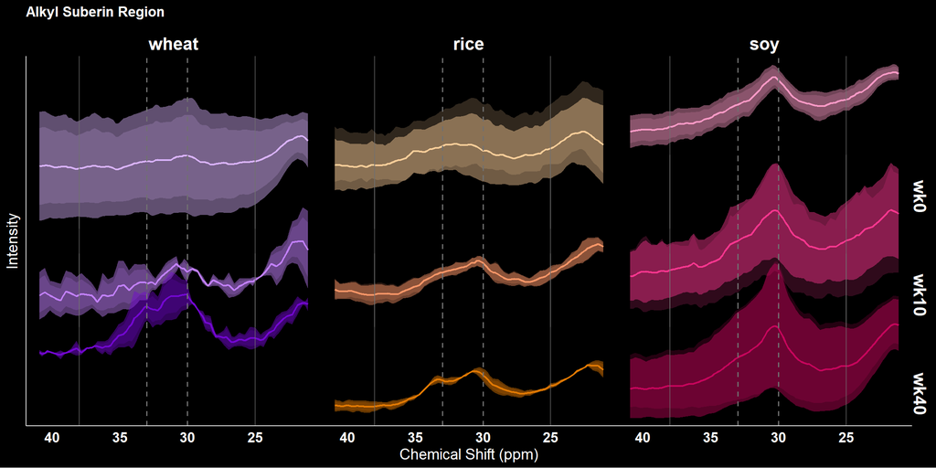

```r
# Save the plot
ggsave_themed(filename = "NMR_spectra_alkyl_region_0-45ppm.png",
              plot = p_alkyl, width = 11, height = 7, dpi = 300)

#############################################################################################
# Just suberin region (30-33 ppm)
############################################################################

spectra_stats_aSub <- spectra_stats %>%
  filter(ppm >= 21 & ppm <= 41)

# Create the zoomed plot
p_aSub <- ggplot(spectra_stats_aSub, aes(x = ppm, y = mean_intensity, color = crop_time, fill = crop_time)) +
  # Full range (most transparent)
  geom_ribbon(aes(ymin = min_intensity, ymax = max_intensity), alpha = 0.19, color = NA) +
  # +/- 1 SD (medium transparency)
  geom_ribbon(aes(ymin = lower_sd, ymax = upper_sd), alpha = 0.44, color = NA) +
  # Mean line (solid)
  geom_line(linewidth = 0.8) +
  # Add vertical reference lines
  geom_vline(xintercept = 33, linetype = "dashed", color = annotation_line_color, linewidth = 0.7) +
  geom_vline(xintercept = 30, linetype = "dashed", color = annotation_line_color, linewidth = 0.7) +
  # suberin integration region bounds
  geom_vline(xintercept = 25, linetype = "solid", color = annotation_line_color, linewidth = 0.45,
  alpha = 0.7) +
  geom_vline(xintercept = 38, linetype = "solid", color = annotation_line_color, linewidth = 0.45,
  alpha = 0.7) +
  facet_grid(timepoint ~ crop, scales = "free_y") +
  scale_x_reverse() +
  scale_color_manual(values = color_map) +
  scale_fill_manual(values = color_map) +
  labs(
    x = "Chemical Shift (ppm)",
    y = "Intensity",
    title = "Alkyl Suberin Region"
  ) +

  theme(
    legend.position = "none",
    strip.text = element_text(size = 16, face = "bold", color = annotation_text_color),
    # strip.background = element_rect(fill = "#1a1a1a"),
    strip.text.y = element_text(margin = margin(t = 40, r = 1, b = -60, l = 0), color = annotation_text_color),
    axis.title = element_text(size = 14),
    panel.grid.major.y = element_blank(),
    panel.grid.minor.y = element_blank(),
    panel.grid.major.x = element_blank(),
    panel.grid.minor.x = element_blank(),
    axis.text.x = element_text(size = 13, face = "bold"),
    axis.text.y = element_blank(),
    panel.spacing.x = unit(0, "cm"),
    panel.spacing.y = unit(-2.4, "cm"),
    panel.grid = element_blank()
  )

# Display the plot
print(p_aSub)
```

```r
# Save the plot
ggsave_themed(filename = "NMR_spectra_aSub_21-41ppm.png",
              plot = p_aSub, width = 12, height = 6, dpi = 300)
```

# Plot Individual Spectra Overlaid by Timepoint

Overlay all individual spectra for each crop with timepoints distinguished by color.

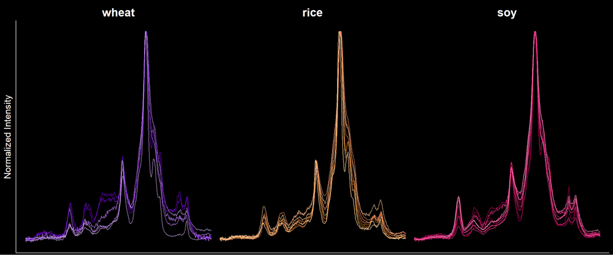

```r
library(ggplot2)
library(dplyr)

# Define color scheme for crops and timepoints
crop_time_colors <- color_map

# Create the plot with individual spectra colored by crop and timepoint
p_individual <- ggplot(spectra_filtered, aes(x = ppm, y = intensity, color = paste(crop, timepoint, sep = "_"), group = sample_name)) +
  geom_line(linewidth = 0.5, alpha = 0.7) +
  facet_grid(. ~ crop, scales = "free_y") +
  scale_x_reverse() +
  scale_color_manual(values = crop_time_colors) +
  labs(
    x = NULL,
    y = "Normalized Intensity",
    title = NULL
  ) +

  theme(
    legend.position = "none",
    strip.text = element_text(size = 16, face = "bold", color = annotation_text_color),
    # strip.background = element_rect(fill = "#1a1a1a"),
    panel.grid.major.x = element_blank(),
    panel.grid.minor.x = element_blank(),
    panel.grid.major.y = element_blank(),
    panel.grid.minor.y = element_blank(),
    axis.title = element_text(size = 13),
    axis.text.x = element_blank(),
    axis.text.y = element_blank(),
    panel.spacing.x = unit(-0.5, "cm"),
    plot.margin = margin(t = 5, r = 5, b = 0, l = 5)
  )

# Display the plot
print(p_individual)
```

```r
# Save the plot
ggsave_themed(filename = "NMR_spectra_individual_overlaid_by_timepoint.png",
              plot = p_individual, width = 12, height = 5, dpi = 300)
```